# eda process

```python
import pandas as pd
import numpy as np

import matplotlib.pyplot as plt
%matplotlib inline

import seaborn as sns

df = pd.read_csv(r'C:\Users\Lenovo\Downloads\Job Market Insights\InternshalaJobs.csv')
df
```

|  | Unnamed: 0 | Position | Company Name | Location | Start Date | CTC (Annual) | Experience | Posted Ago | Role |
| --- | --- | --- | --- | --- | --- | --- | --- | --- | --- |
| 0 | 0 | Junior Interior Designer | Dexterio Private Limited | Jaipur | Starts Immediately | ₹ 2,00,000 - 2,40,000 | 0-2 years | 3 weeks ago | Job |
| 1 | 1 | Business Development Representative - B2B SaaS | Zylu Business Solutions Private Limited | Bangalore | Starts Immediately | ₹ 3,00,000 - 5,00,000 | 0-5 years | 1 day ago | Job |
| 2 | 2 | Corporate Sales Specialist | Hot Stuffs Private Limited | Mumbai | Starts Immediately | ₹ 2,10,000 - 3,00,000 | 0-2 years | 6 days ago | Job |
| 3 | 3 | Career Guidance Expert - Sales | NxtWave Disruptive Technologies Private Limited | Work from home | Starts Immediately | ₹ 3,00,000 - 6,00,000 | 0-5 years | 2 weeks ago | Job |
| 4 | 4 | Video Content Creator | ReThought Technologies Private Limited | Delhi | Starts Immediately | ₹ 2,00,000 - 3,00,000 | 0-2 years | 2 weeks ago | Job |
| ... | ... | ... | ... | ... | ... | ... | ... | ... | ... |
| 404 | 404 | Business Development Executive | Mohite Consultancy Services (MCS) | Koramangala | Starts Immediately | ₹ 2,16,000 - 2,40,000 | 0-2 years | 1 week ago | Job |
| 405 | 405 | Engagement Strategist | OpeninApp | Bangalore | Starts Immediately | ₹ 2,00,000 - 8,00,000 | 0-5 years | 1 week ago | Job |
| 406 | 406 | Brand Partnerships Associate | Confluencr | Bangalore | Starts Immediately | ₹ 3,00,000 - 4,50,000 | 0-2 years | 6 days ago | Job |
| 407 | 407 | Business Development Executive | Nerdy Academy | Mumbai | Starts Immediately | ₹ 2,40,000 - 5,80,000 | 0-5 years | 3 weeks ago | Job |
| 408 | 408 | Junior Lead Generation Associate | Fabulous Media Private Limited | Gurgaon | Starts Immediately | ₹ 2,00,000 - 3,00,000 | 0-2 years | 5 days ago | Job |

409 rows × 9 columns

### Preferred Combinations

1. Position and Location
2. Position and CTC (Annual)
3. CTC (Annual) and Location
4. Position and Company Name (PASSION)
5. CTC (Annual) and Experience (EXPERIENCED)
6. Location and Posted Ago (FRESHERS)

# 1. Univariate analysis

In the exploratory data analysis (EDA) process, I have included the "Location" column as a univariate categorical variable in our dataframes. The purpose of incorporating this column is to discern the presence of an abundance of job postings in a specific city.

By utilizing the "Location" column, I can now effectively isolate and analyze job postings within a particular city. This allows us to answer questions such as:

1. How many job postings are associated with a specific city in our dataset?
2. Which cities have the highest number of job postings?
3. Are there any cities where job postings are significantly more prevalent than others?

In essence, the inclusion of the "Location" column as a univariate categorical variable serves as a crucial step in our analysis to identify cities with a substantial number of job postings. This information can be instrumental in understanding regional job market trends, focusing recruitment efforts, or making informed decisions related to business operations in specific locations.

### Total number of jobs available in different cities

```python
df['Location'].value_counts()
```

```
Mumbai                                                                                                                                           72
Bangalore                                                                                                                                        51
Delhi                                                                                                                                            40
Noida                                                                                                                                            23
Gurgaon                                                                                                                                          20
                                                                                                                                                 ..
Sohna, Delhi, Gurgaon                                                                                                                             1
Faridabad                                                                                                                                         1
Delhi, Faridabad, Gurgaon, Noida                                                                                                                  1
Indore, Lucknow, Patna, Delhi, Pune, Gujarat, Hyderabad, Bhopal, Ranchi, Mumbai, Warangal, Secunderabad, Vijayawada, Vishakhapatnam, Begumpet     1
Koramangala                                                                                                                                       1
Name: Location, Length: 92, dtype: int64
```

### Total number of jobs available in different cities representing using countplot

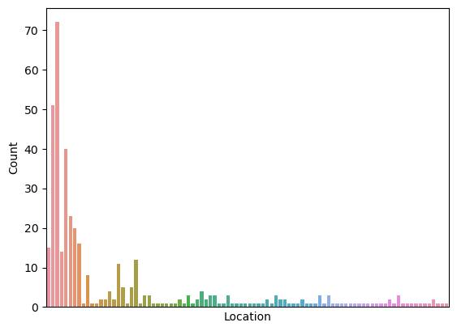

```python
sns.countplot(x='Location',data=df)
plt.xlabel('Location')
plt.ylabel('Count')
plt.xticks([])
plt.show()
```

`The above information is useless so I'am performing analysis for top 15 rows with 9 columns`

### Top 15 cities with highest availability of jobs

```python
df['Location'].value_counts().head(15)
```

```
Mumbai            72
Bangalore         51
Delhi             40
Noida             23
Gurgaon           20
Indore            16
Jaipur            15
Work from home    14
Chennai           12
Hyderabad         11
Pune               8
Ahmedabad          5
Kolkata            5
Indore, Bhopal     4
Gurgaon, Delhi     4
Name: Location, dtype: int64
```

### Top 15 cities with highest availability of jobs representing using bars

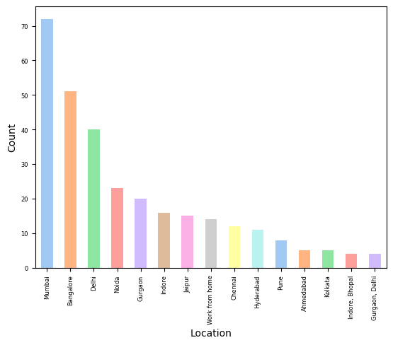

```python
colors = sns.color_palette('pastel')[0:15]
df['Location'].value_counts().head(15).plot.bar(color=colors,fontsize=6)
plt.xlabel('Location')
plt.ylabel('Count')
plt.show()
```

### Top 15 Positions that had huge demand now-a-days

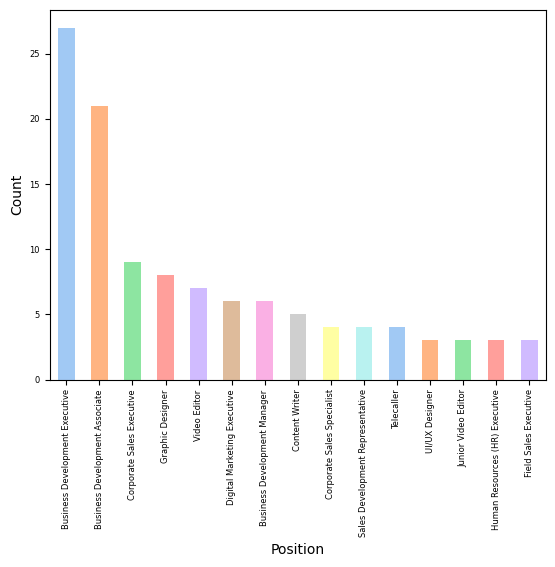

```python
colors = sns.color_palette('pastel')[0:15]
df['Position'].value_counts().head(15).plot.bar(color=colors,fontsize=6)
plt.xlabel('Position')
plt.ylabel('Count')
plt.show()
```

### Top 15 Companies that were posting many jobs now-a-days

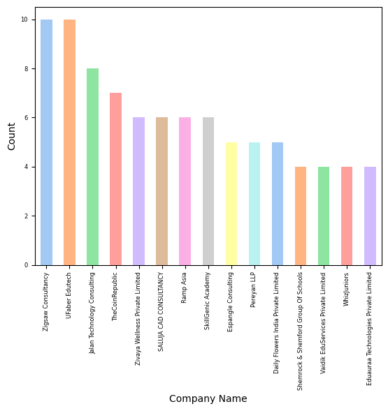

```python
colors = sns.color_palette('pastel')[0:15]
df['Company Name'].value_counts().head(15).plot.bar(color=colors,fontsize=6)
plt.xlabel('Company Name')
plt.ylabel('Count')
plt.show()
```

### Top 15 offered CTC (Annual) by different companies

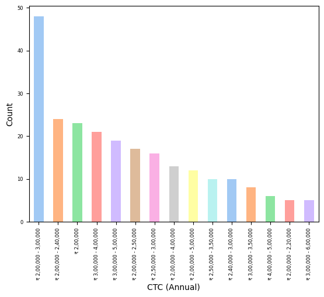

```python
colors = sns.color_palette('pastel')[0:15]
df['CTC (Annual)'].value_counts().head(15).plot.bar(color=colors,fontsize=6)
plt.xlabel('CTC (Annual)')
plt.ylabel('Count')
plt.show()
```

### Common experience that were chosen more likely by companies

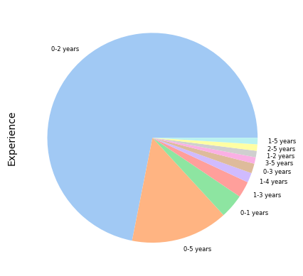

```python
colors = sns.color_palette('pastel')[0:10]
df['Experience'].value_counts().head(10).plot.pie(colors=colors,fontsize=6);
plt.show()
```

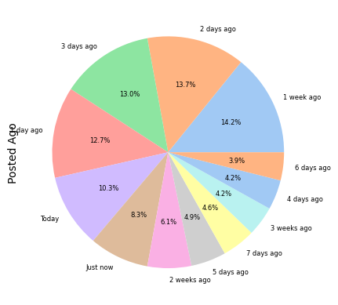

```python
colors = sns.color_palette('pastel')[0:15]
df['Posted Ago'].value_counts().head(15).plot.pie(autopct="%.1f%%",colors=colors,fontsize=6);
plt.show()
```

# 2. Bivariate analysis

### Categorical vs Categorical

- Location
- Posted Ago

In the exploratory data analysis (EDA) process, I incorporated two bivariate categorical columns: "Location" and "Posted Ago." These columns were chosen to facilitate an analysis aimed at identifying trends and patterns related to recent job postings in a specific city.

The "Location" column categorizes the job postings based on their geographical location, likely including various cities or regions. On the other hand, the "Posted Ago" column categorizes the job postings based on when they were posted, possibly utilizing time intervals such as days, weeks, or months.

By combining these two categorical columns, I can now analyze the data to discern patterns related to job postings in a particular city and their recency. This approach enables us to answer questions such as:

1. How many job postings have been made in a specific city within a certain time frame?
2. Are there certain cities that have experienced a surge in job postings recently?
3. Do different cities exhibit varying patterns in the frequency and recency of job postings?

In summary, the inclusion of the "Location" and "Posted Ago" columns in our EDA process allows us to gain valuable insights into the dynamics of job postings, particularly focusing on the frequency and timing of these postings in specific cities. This information can be crucial for various decision-making processes, such as recruitment strategies or market trend analysis.

### Cross-tabulation of cities with recent posted number of jobs

```python
crosstab=pd.crosstab(df['Location'], df['Posted Ago'])
crosstab
```

| Posted Ago Location | 1 day ago | 1 week ago | 2 days ago | 2 weeks ago | 3 days ago | 3 weeks ago | 4 days ago | 5 days ago | 6 days ago | 7 days ago | Just now | Today |
| --- | --- | --- | --- | --- | --- | --- | --- | --- | --- | --- | --- | --- |
| Agra | 0 | 0 | 0 | 0 | 2 | 0 | 0 | 0 | 0 | 0 | 0 | 0 |
| Ahmedabad | 1 | 0 | 0 | 3 | 0 | 0 | 0 | 1 | 0 | 0 | 0 | 0 |
| Ahmedabad, Jamshedpur | 0 | 0 | 0 | 0 | 0 | 0 | 0 | 0 | 0 | 1 | 0 | 0 |
| Alwar, Delhi, Gurgaon, Neemrana, Noida | 0 | 1 | 0 | 0 | 0 | 0 | 0 | 0 | 0 | 0 | 0 | 0 |
| Ambala | 0 | 0 | 0 | 0 | 0 | 0 | 0 | 0 | 0 | 0 | 0 | 1 |
| ... | ... | ... | ... | ... | ... | ... | ... | ... | ... | ... | ... | ... |
| Varanasi | 0 | 0 | 0 | 3 | 0 | 0 | 0 | 0 | 0 | 0 | 0 | 0 |
| Vijayawada, Cochin, Visakhapatnam, Bangalore, Hyderabad, Coimbatore, Madurai | 0 | 0 | 0 | 0 | 0 | 0 | 0 | 0 | 0 | 0 | 1 | 0 |
| Visakhapatnam | 0 | 0 | 0 | 1 | 0 | 0 | 0 | 2 | 0 | 0 | 0 | 0 |
| Vishakhapatnam | 0 | 0 | 1 | 0 | 0 | 0 | 0 | 0 | 0 | 0 | 0 | 0 |
| Work from home | 0 | 0 | 0 | 1 | 0 | 0 | 0 | 0 | 0 | 0 | 5 | 8 |

92 rows × 12 columns

### Cross-tabulation of two categorical columns representing using bars

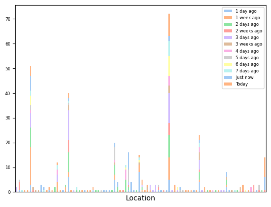

```python
colors = sns.color_palette('pastel')[0:15]
crosstab.plot(kind="bar",stacked=True,color=colors,fontsize=6)
plt.xticks([])
plt.legend(fontsize=6)
plt.show()
```

`The above information is useless so I'am performing analysis for top 15 rows with 9 columns`

```python
df[['Location']].head(15)
```

|  | Location |
| --- | --- |
| 0 | Jaipur |
| 1 | Bangalore |
| 2 | Mumbai |
| 3 | Work from home |
| 4 | Delhi |
| 5 | Noida |
| 6 | Delhi |
| 7 | Mumbai |
| 8 | Gurgaon |
| 9 | Indore |
| 10 | Indore |
| 11 | Indore |
| 12 | Indore |
| 13 | Indore |
| 14 | Mumbai |

```python
df[['Posted Ago']].head(15)
```

|  | Posted Ago |
| --- | --- |
| 0 | 3 weeks ago |
| 1 | 1 day ago |
| 2 | 6 days ago |
| 3 | 2 weeks ago |
| 4 | 2 weeks ago |
| 5 | 2 weeks ago |
| 6 | 2 weeks ago |
| 7 | 1 week ago |
| 8 | 4 days ago |
| 9 | Just now |
| 10 | Just now |
| 11 | Just now |
| 12 | Just now |
| 13 | Just now |
| 14 | Just now |

### Cross-tabulation of two categorical columns (Location and Posted Ago)

```python
crosstab=pd.crosstab(df['Location'].head(15), df['Posted Ago'].head(15))
crosstab
```

| Posted Ago Location | 1 day ago | 1 week ago | 2 weeks ago | 3 weeks ago | 4 days ago | 6 days ago | Just now |
| --- | --- | --- | --- | --- | --- | --- | --- |
| Bangalore | 1 | 0 | 0 | 0 | 0 | 0 | 0 |
| Delhi | 0 | 0 | 2 | 0 | 0 | 0 | 0 |
| Gurgaon | 0 | 0 | 0 | 0 | 1 | 0 | 0 |
| Indore | 0 | 0 | 0 | 0 | 0 | 0 | 5 |
| Jaipur | 0 | 0 | 0 | 1 | 0 | 0 | 0 |
| Mumbai | 0 | 1 | 0 | 0 | 0 | 1 | 1 |
| Noida | 0 | 0 | 1 | 0 | 0 | 0 | 0 |
| Work from home | 0 | 0 | 1 | 0 | 0 | 0 | 0 |

### Cross-tabulation of two categorical columns representing using bars

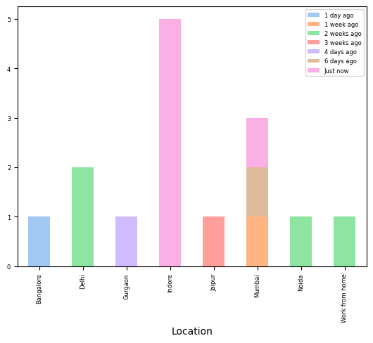

```python
colors = sns.color_palette('pastel')[0:15]
crosstab.plot(kind="bar",stacked=True,color=colors,fontsize=6)
plt.legend(fontsize=6)
plt.show()
```

### Categorical vs Categorical

- Position
- Company Name

In our recent exploratory data analysis (EDA) process, we adopted a strategic approach to gain insights into the job market in a specific city. To achieve this, we utilized two key categorical columns from our dataset: "Position" and "Company Name."

1. **Position:** By considering the "Position" column, we aimed to understand the types of job roles being advertised in the city. This helped us identify the most in-demand job positions and explore trends or patterns in job titles over time.
2. **Company Name:** The "Company Name" column allowed us to assess the organizations that were actively posting job openings in the city. This analysis provided insights into which companies were expanding their workforce and potentially thriving in the local job market.

By examining the interplay between these two categorical columns, we gained a comprehensive perspective on recent job postings in the city. This bivariate approach enabled us to answer critical questions such as:

1. Which positions are in high demand, and which companies are offering these roles?
2. Are specific companies dominating the job market, or is there a diverse range of employers?
3. Have there been any noticeable shifts in the types of positions offered by different companies over time?

This methodology has provided us with valuable insights into the dynamics of the job market in our chosen city, allowing us to make informed decisions and recommendations based on our findings.

This approach allows you to explain how you used "Position" and "Company Name" as bivariate categorical columns to analyze recent job postings in a specific city, providing a clear understanding of your EDA process.

### Cross-tabulation of two categorical columns (Position and Company Name)

```python
crosstab=pd.crosstab(df['Company Name'].head(15), df['Position'].head(15))
crosstab
```

| Position Company Name | Business Development Associate (International Sales) | Business Development Executive | Business Development Manager | Business Development Representative - B2B SaaS | Career Guidance Expert - Sales | Corporate Sales Specialist | Digital Marketing Executive | HR Executive | Junior Interior Designer | Operations Associate | SEO And Google Ads Executive | Senior Content Writer | Social Media Executive | Social Media Marketing Manager | Video Content Creator |
| --- | --- | --- | --- | --- | --- | --- | --- | --- | --- | --- | --- | --- | --- | --- | --- |
| Dexterio Private Limited | 0 | 0 | 0 | 0 | 0 | 0 | 0 | 0 | 1 | 0 | 0 | 0 | 0 | 0 | 0 |
| Empirical F & M Academy | 0 | 1 | 0 | 0 | 0 | 0 | 0 | 0 | 0 | 0 | 0 | 0 | 0 | 0 | 0 |
| HireDesigners | 0 | 0 | 0 | 0 | 0 | 0 | 0 | 0 | 0 | 0 | 1 | 0 | 0 | 0 | 0 |
| Hot Stuffs Private Limited | 0 | 0 | 0 | 0 | 0 | 1 | 0 | 0 | 0 | 0 | 0 | 0 | 0 | 0 | 0 |
| Internshala | 1 | 0 | 0 | 0 | 0 | 0 | 0 | 0 | 0 | 0 | 0 | 0 | 0 | 0 | 0 |
| NxtWave Disruptive Technologies Private Limited | 0 | 0 | 0 | 0 | 1 | 0 | 0 | 0 | 0 | 0 | 0 | 0 | 0 | 0 | 0 |
| ReThought Technologies Private Limited | 0 | 0 | 0 | 0 | 0 | 0 | 0 | 0 | 0 | 0 | 0 | 0 | 0 | 1 | 1 |
| Tyke Technology Private Limited | 0 | 0 | 0 | 0 | 0 | 0 | 0 | 0 | 0 | 1 | 0 | 0 | 0 | 0 | 0 |
| Zivaya Wellness Private Limited | 0 | 0 | 1 | 0 | 0 | 0 | 1 | 1 | 0 | 0 | 0 | 1 | 1 | 0 | 0 |
| Zylu Business Solutions Private Limited | 0 | 0 | 0 | 1 | 0 | 0 | 0 | 0 | 0 | 0 | 0 | 0 | 0 | 0 | 0 |

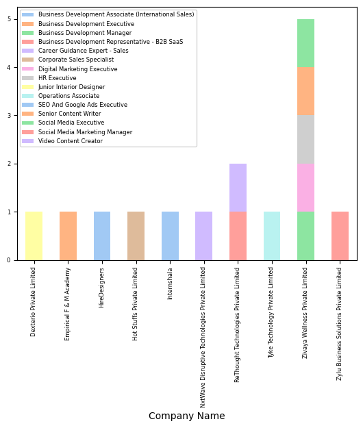

```python
colors = sns.color_palette('pastel')[0:15]
crosstab.plot(kind="bar",stacked=True,color=colors,fontsize=6)
plt.legend(fontsize=6)
plt.show()
```

### Categorical vs Categorical

- Experience
- CTC (Annual)

In my recent data analysis process, I utilized two bivariant categorical columns: "Experience" and "CTC (Annual)." These columns were crucial components of my exploratory data analysis (EDA) as they allowed me to establish a relationship between an individual's experience and their annual income.

By examining the data within these columns, I aimed to demonstrate that one's level of experience can significantly impact their annual income. This analysis can be valuable for making informed decisions about career choices and potential income growth, helping individuals understand that with a particular level of experience, they can expect to earn a certain amount annually.

In summary, the inclusion of the "Experience" and "CTC (Annual)" columns in the EDA process allowed me to explore the connection between experience and income, providing insights that can assist individuals in setting realistic income expectations based on their experience level.

### Cross-tabulation of two categorical columns (Experience and CTC (Annual))

```python
crosstab=pd.crosstab(df['CTC (Annual)'].head(15), df['Experience'].head(15))
crosstab
```

| Experience CTC (Annual) | 0-2 years | 0-5 years |
| --- | --- | --- |
| ₹ 2,00,000 - 2,40,000 | 1 | 0 |
| ₹ 2,00,000 - 3,00,000 | 2 | 0 |
| ₹ 2,00,000 - 3,50,000 | 1 | 0 |
| ₹ 2,00,000 - 3,60,000 | 2 | 0 |
| ₹ 2,00,000 - 4,20,000 | 1 | 0 |
| ₹ 2,00,000 - 4,80,000 | 3 | 0 |
| ₹ 2,10,000 - 3,00,000 | 1 | 0 |
| ₹ 2,40,000 - 2,70,000 | 1 | 0 |
| ₹ 3,00,000 - 5,00,000 | 0 | 1 |
| ₹ 3,00,000 - 6,00,000 | 0 | 1 |
| ₹ 3,60,000 - 4,00,000 | 1 | 0 |

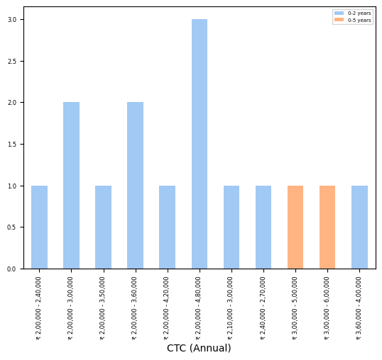

```python
colors = sns.color_palette('pastel')[0:15]
crosstab.plot(kind="bar",stacked=True,color=colors,fontsize=6)
plt.legend(fontsize=5)
plt.show()
```

### Categorical Vs Categorical

- Position
- CTC (Annual)

In our exploratory data analysis (EDA) process, we have chosen to examine the relationship between two important categorical variables: "Position" and "CTC (Annual)." This decision is pivotal as it allows us to uncover valuable insights into the correlation between one's job position and their annual income.

By considering "Position" as one of our categorical variables, we can gain a comprehensive understanding of how different job roles or titles impact an individual's earning potential. This is significant because it not only sheds light on income disparities within our dataset but also provides actionable insights for individuals aiming to increase their earnings.

Furthermore, "CTC (Annual)" being another categorical variable in our analysis enables us to categorize income levels into distinct groups. By associating specific positions with corresponding income categories, we can clearly communicate the relationship between position and income. This information is invaluable for career planning and negotiations, as it demonstrates that with higher positions, one can potentially attain a higher annual income.

In summary, our choice to treat "Position" and "CTC (Annual)" as bivariate categorical columns in our EDA process is essential for uncovering patterns and relationships that will not only enrich our understanding of the data but also offer practical insights for career development and financial planning.

### Cross-tabulation of two categorical columns (Position and CTC (Annual))

```python
crosstab=pd.crosstab(df['CTC (Annual)'].head(15), df['Position'].head(15))
crosstab
```

| Position CTC (Annual) | Business Development Associate (International Sales) | Business Development Executive | Business Development Manager | Business Development Representative - B2B SaaS | Career Guidance Expert - Sales | Corporate Sales Specialist | Digital Marketing Executive | HR Executive | Junior Interior Designer | Operations Associate | SEO And Google Ads Executive | Senior Content Writer | Social Media Executive | Social Media Marketing Manager | Video Content Creator |
| --- | --- | --- | --- | --- | --- | --- | --- | --- | --- | --- | --- | --- | --- | --- | --- |
| ₹ 2,00,000 - 2,40,000 | 0 | 0 | 0 | 0 | 0 | 0 | 0 | 0 | 1 | 0 | 0 | 0 | 0 | 0 | 0 |
| ₹ 2,00,000 - 3,00,000 | 0 | 1 | 0 | 0 | 0 | 0 | 0 | 0 | 0 | 0 | 0 | 0 | 0 | 0 | 1 |
| ₹ 2,00,000 - 3,50,000 | 0 | 0 | 0 | 0 | 0 | 0 | 0 | 0 | 0 | 0 | 0 | 0 | 0 | 1 | 0 |
| ₹ 2,00,000 - 3,60,000 | 0 | 0 | 0 | 0 | 0 | 0 | 0 | 1 | 0 | 0 | 1 | 0 | 0 | 0 | 0 |
| ₹ 2,00,000 - 4,20,000 | 0 | 0 | 0 | 0 | 0 | 0 | 0 | 0 | 0 | 0 | 0 | 0 | 1 | 0 | 0 |
| ₹ 2,00,000 - 4,80,000 | 0 | 0 | 1 | 0 | 0 | 0 | 1 | 0 | 0 | 0 | 0 | 1 | 0 | 0 | 0 |
| ₹ 2,10,000 - 3,00,000 | 0 | 0 | 0 | 0 | 0 | 1 | 0 | 0 | 0 | 0 | 0 | 0 | 0 | 0 | 0 |
| ₹ 2,40,000 - 2,70,000 | 0 | 0 | 0 | 0 | 0 | 0 | 0 | 0 | 0 | 1 | 0 | 0 | 0 | 0 | 0 |
| ₹ 3,00,000 - 5,00,000 | 0 | 0 | 0 | 1 | 0 | 0 | 0 | 0 | 0 | 0 | 0 | 0 | 0 | 0 | 0 |
| ₹ 3,00,000 - 6,00,000 | 0 | 0 | 0 | 0 | 1 | 0 | 0 | 0 | 0 | 0 | 0 | 0 | 0 | 0 | 0 |
| ₹ 3,60,000 - 4,00,000 | 1 | 0 | 0 | 0 | 0 | 0 | 0 | 0 | 0 | 0 | 0 | 0 | 0 | 0 | 0 |

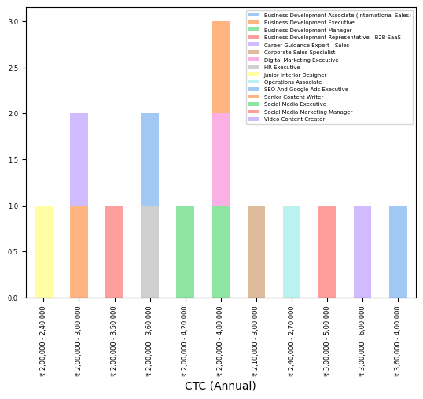

```python
colors = sns.color_palette('pastel')[0:15]
crosstab.plot(kind="bar",stacked=True,color=colors,fontsize=6)
plt.legend(fontsize=5)
plt.show()
```

### Categorical Vs Categorical

- Location
- CTC (Annual)

In the exploratory data analysis (EDA) process, I selected "Location" and "CTC (Annual)" as two bivariate categorical columns for analysis. This choice allows us to examine the relationship between the location (city) and the annual compensation (CTC) of individuals in our dataset. By considering these two variables together, we can gain insights into whether there is a correlation between a specific city and higher annual salaries.

The objective is to identify if there is a pattern suggesting that individuals in a particular city tend to receive higher annual compensation compared to those in other cities. By analyzing these two categorical variables in tandem, we can potentially uncover valuable information that may help us understand salary variations across different locations. This analysis could provide insights into regional salary trends, cost of living differences, or job market dynamics, enabling us to make informed decisions or recommendations related to compensation and location choices.

### Cross-tabulation of two categorical columns (Location and CTC (Annual))

```python
crosstab=pd.crosstab(df['CTC (Annual)'].head(15), df['Location'].head(15))
crosstab
```

| Location CTC (Annual) | Bangalore | Delhi | Gurgaon | Indore | Jaipur | Mumbai | Noida | Work from home |
| --- | --- | --- | --- | --- | --- | --- | --- | --- |
| ₹ 2,00,000 - 2,40,000 | 0 | 0 | 0 | 0 | 1 | 0 | 0 | 0 |
| ₹ 2,00,000 - 3,00,000 | 0 | 1 | 0 | 0 | 0 | 1 | 0 | 0 |
| ₹ 2,00,000 - 3,50,000 | 0 | 1 | 0 | 0 | 0 | 0 | 0 | 0 |
| ₹ 2,00,000 - 3,60,000 | 0 | 0 | 0 | 1 | 0 | 0 | 1 | 0 |
| ₹ 2,00,000 - 4,20,000 | 0 | 0 | 0 | 1 | 0 | 0 | 0 | 0 |
| ₹ 2,00,000 - 4,80,000 | 0 | 0 | 0 | 3 | 0 | 0 | 0 | 0 |
| ₹ 2,10,000 - 3,00,000 | 0 | 0 | 0 | 0 | 0 | 1 | 0 | 0 |
| ₹ 2,40,000 - 2,70,000 | 0 | 0 | 0 | 0 | 0 | 1 | 0 | 0 |
| ₹ 3,00,000 - 5,00,000 | 1 | 0 | 0 | 0 | 0 | 0 | 0 | 0 |
| ₹ 3,00,000 - 6,00,000 | 0 | 0 | 0 | 0 | 0 | 0 | 0 | 1 |
| ₹ 3,60,000 - 4,00,000 | 0 | 0 | 1 | 0 | 0 | 0 | 0 | 0 |

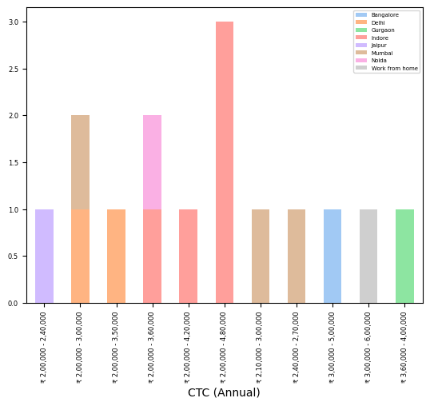

```python
colors = sns.color_palette('pastel')[0:15]
crosstab.plot(kind="bar",stacked=True,color=colors,fontsize=6)
plt.legend(fontsize=5)
plt.show()
```

### Categorical Vs Categorical

- Position
- Location

In our EDA process, we have chosen to focus on the relationship between two key categorical variables: "Position" and "Location." This choice allows us to gain valuable insights into how the position of individuals or job openings relates to their preferred work locations.

**Position:**

- The "Position" variable represents different job titles or roles within our dataset. By examining this variable, we can understand the distribution of positions across our data.

**Location:**

- "Desired Location" is another categorical variable that signifies the geographical preferences or locations individuals or job openings aspire to work in. Analyzing this variable can uncover trends in location preferences.

**Bivariate Analysis:** By treating "Position" and "Location" as bivariate categorical columns, we aim to explore the interplay between these two factors. This analysis will help us answer questions such as:

1. Which positions are most commonly associated with specific desired locations?
2. Are there any regional preferences for certain roles?
3. Do particular positions have a stronger presence in certain locations?

Understanding these relationships can be instrumental in tailoring our strategies, whether it's optimizing job postings, recruitment efforts, or even employee placement, to align with the preferences and trends revealed by this bivariate analysis.

In summary, our EDA process leverages "Position" and "Location" as key bivariate categorical variables to uncover meaningful insights into the relationship between job roles and geographic preferences within our dataset.

### Cross-tabulation of two categorical columns (Position and Location)

```python
crosstab=pd.crosstab(df['Location'].head(15), df['Position'].head(15))
crosstab
```

| Position Location | Business Development Associate (International Sales) | Business Development Executive | Business Development Manager | Business Development Representative - B2B SaaS | Career Guidance Expert - Sales | Corporate Sales Specialist | Digital Marketing Executive | HR Executive | Junior Interior Designer | Operations Associate | SEO And Google Ads Executive | Senior Content Writer | Social Media Executive | Social Media Marketing Manager | Video Content Creator |
| --- | --- | --- | --- | --- | --- | --- | --- | --- | --- | --- | --- | --- | --- | --- | --- |
| Bangalore | 0 | 0 | 0 | 1 | 0 | 0 | 0 | 0 | 0 | 0 | 0 | 0 | 0 | 0 | 0 |
| Delhi | 0 | 0 | 0 | 0 | 0 | 0 | 0 | 0 | 0 | 0 | 0 | 0 | 0 | 1 | 1 |
| Gurgaon | 1 | 0 | 0 | 0 | 0 | 0 | 0 | 0 | 0 | 0 | 0 | 0 | 0 | 0 | 0 |
| Indore | 0 | 0 | 1 | 0 | 0 | 0 | 1 | 1 | 0 | 0 | 0 | 1 | 1 | 0 | 0 |
| Jaipur | 0 | 0 | 0 | 0 | 0 | 0 | 0 | 0 | 1 | 0 | 0 | 0 | 0 | 0 | 0 |
| Mumbai | 0 | 1 | 0 | 0 | 0 | 1 | 0 | 0 | 0 | 1 | 0 | 0 | 0 | 0 | 0 |
| Noida | 0 | 0 | 0 | 0 | 0 | 0 | 0 | 0 | 0 | 0 | 1 | 0 | 0 | 0 | 0 |
| Work from home | 0 | 0 | 0 | 0 | 1 | 0 | 0 | 0 | 0 | 0 | 0 | 0 | 0 | 0 | 0 |

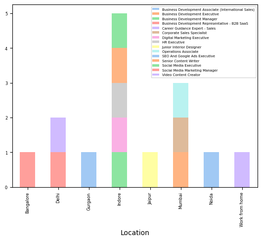

```python
colors = sns.color_palette('pastel')[0:15]
crosstab.plot(kind="bar",stacked=True,color=colors,fontsize=6)
plt.legend(fontsize=5)
plt.show()
```

# 3. Multivariate analysis

### Combination of 3 categorical columns are represented using lines

In the exploratory data analysis (EDA) process, I have included three multivariate categorical columns: "Location," "Posted Ago," and "Start Date." This strategic choice of variables enables us to identify opportunities where you can quickly find and secure job appointments in a specific city.

Here's how these columns contribute to our analysis:

1. **Location:** The "Location" column categorizes job postings based on their geographical location, such as cities or regions. This allows us to pinpoint cities of interest where you are looking for job opportunities.
2. **Posted Ago:** The "Posted Ago" column categorizes job postings based on when they were posted, indicating their recency. This information helps identify recent job listings, which are often more relevant and likely to result in quicker appointments.
3. **Start Date:** The "Start Date" column provides insights into when the job positions are scheduled to begin. This can be essential in understanding the urgency of job openings and whether they align with your desired timeline for starting a new position.

By combining these three categorical columns, we can perform the following analyses:

- Identify cities with a high frequency of recent job postings, indicating a potentially active job market.
- Filter job postings based on recency, allowing you to focus on opportunities that have been posted recently.
- Match job listings with start dates that align with your preferred timeline, enabling you to quickly find and apply for positions that suit your schedule.

Overall, the inclusion of these multivariate categorical columns enhances our EDA process, empowering us to pinpoint cities with abundant recent job postings. This strategic approach can facilitate a more efficient job search, increasing your chances of securing appointments quickly in a city of your choice.

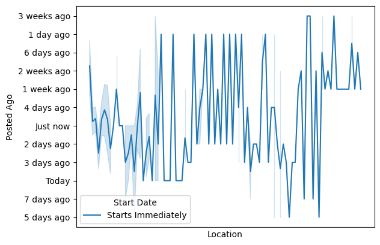

```python
sns.lineplot(x="Location",y="Posted Ago",hue='Start Date',data=df)
plt.xticks([])
plt.show()
```

In the exploratory data analysis (EDA) process, I have included three multivariate categorical columns: "Location," "Posted Ago," and "Role" in our dataframes. This strategic choice allows us to gain a multifaceted understanding of job postings in specific cities while considering their recency and job type.

Here's how these columns contribute to our analysis:

1. **Location:** The "Location" column categorizes job postings based on their geographical location, which includes various cities or regions. This allows us to pinpoint specific cities and analyze job postings within them.
2. **Posted Ago:** The "Posted Ago" column categorizes job postings based on when they were posted, typically using time intervals such as days, weeks, or months. This information enables us to identify recent job postings, which can be valuable in assessing the current job market.
3. **Role:** The "Role" column categorizes job postings based on the type of job, distinguishing between full-time positions and part-time positions or potentially other roles. This categorization helps us understand the diversity of job opportunities available in specific cities.

With these three multivariate categorical columns, we can address complex questions, such as:

1. How many job postings are currently available in a particular city?
2. What types of jobs (full-time, part-time, etc.) are prevalent in that city?
3. Are there any trends in the recency of job postings within specific roles in different cities?

By integrating these columns into our EDA process, we can provide a comprehensive analysis that not only highlights the abundance of job postings in particular cities but also offers insights into the types of positions available, whether they are full-time or part-time. This information can be instrumental in tailoring recruitment strategies, understanding the job market landscape, and making informed decisions related to job search or business operations.

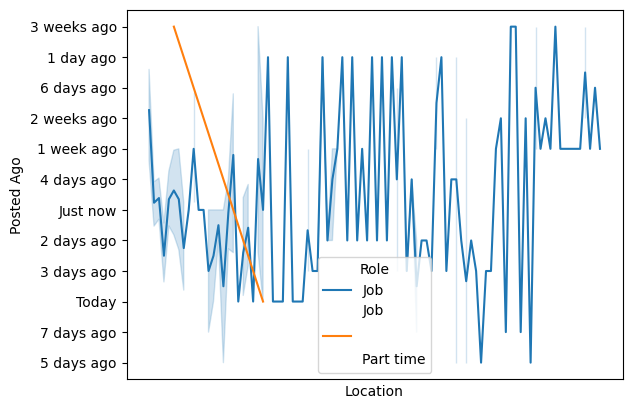

```python
sns.lineplot(x="Location",y="Posted Ago",hue='Role',data=df)
plt.xticks([])
plt.show()
```

# RESULTS

# FINAL ASSUMPTION :

# CONCLUSION

> In conclusion, each of these eight attributes plays a vital role in a fresher's job search. Freshers should carefully consider their preferences, expectations, and goals when exploring job opportunities, using the insights gained from analyzing these attributes to make informed decisions about their career paths. Additionally, staying updated with recent job postings and conducting thorough research on companies can significantly enhance the job search experience for freshers.